# GGPLOT2_R4DS

GGPLOT is used to make plots. the general syntax is as shown below ggplot(data = ) + (mapping = aes( color = )

```r
library(tidyverse)
```

setting aesthetic propertiesmanually.e.g. making all points in our plot blue

```r
ggplot(data = mpg)+
  geom_point(mapping = aes(x = displ, y = hwy) ,colour = "blue" )
#mapping on categorical variable
ggplot(data = mpg)+
  geom_point(mapping = aes(x = displ, y = hwy, colour = displ  < 5)  )
```

FACETS a useful way to adding additional variables for categorical variables, is to split your plot into facets, subplots that each display one subset of the data.

To facet your plot by a single variable, use facet_wrap(). The first argument of facet_wrap() should be a formula, which you create with ~ followed by a variable name ( “formula” is the name of a data structure in R, not a synonym for “equation”). The variable that you pass to facet_wrap() should be discrete:

```r
ggplot(data = mpg)+
  geom_point(mapping = aes(x =displ, y = hwy, color = class))+
  facet_wrap(~class , nrow = 2)
```

To facet the plot with a combination of two variables

```r
ggplot(data = mpg)+
  geom_point(mapping = aes(x =displ, y = hwy, color = class))+
  facet_grid(drv ~ cyl) #or +facet_grid(. ~ cyl)
#faceting on a continuous variable
ggplot(data = mpg)+
  geom_point(mapping = aes(x =displ, y = hwy, color = class))+
  facet_grid(hwy ~ cyl)
#How empty cells relate to this plot
ggplot(data = mpg) +  geom_point(mapping = aes(x = drv, y = cyl))
```

GEOMS To change the geom in your plot, change the geom function that you add to ggplot() Every geom function in ggplot2 takes a mapping argument. However, not every aesthetic works with every geom.

[figure not shown]

Plotting multiple geoms in the same plot

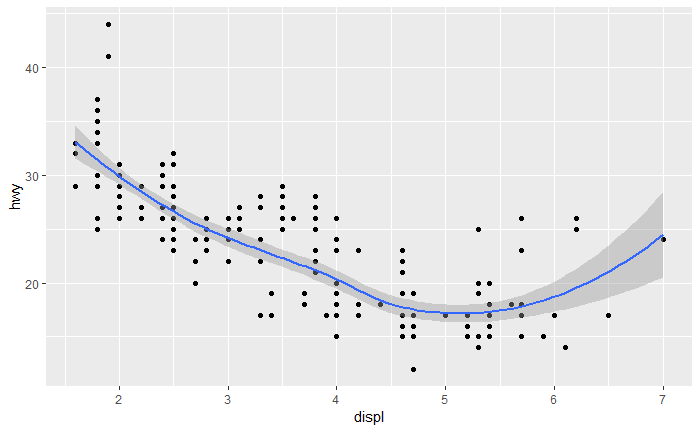

mappings passed into ggplot fn are treated as global variables. thus a quick way to make multiple geoms without having to repeat the code is as illustrated below:

```r
ggplot(data = mpg, mapping = aes(x = displ, y = hwy))+
  geom_point()+
  geom_smooth()

#applying different aesthetics on different layers
ggplot(data = mpg, mapping = aes(x = displ, y = hwy)) +
  geom_point(mapping = aes(color = class)) +
  geom_smooth()
```

```r
ggplot(data = mpg, mapping = aes(x=displ, y=hwy))+
  geom_point(mapping = aes(colour = class))+
  geom_smooth(
    data = filter(mpg, class == "subcompact"),
    se = FALSE
  )

#exe
ggplot(  data = mpg,  mapping = aes(x = displ, y = hwy, color = drv) ) +
  geom_point() +
  geom_smooth(se = FALSE)
```

Statistical transformations

```r
ggplot(data = diamonds)+
  geom_bar(mapping = aes(x=cut))
#or
ggplot(data = diamonds)+
stat_count(mapping = aes(x = cut))
```

changind the statistical transformation (Stat)

```r
demo = tribble(
  ~a, ~b,
  "bar_1", 20,
  "bar_2", 43,
  "bar_3",30
)
ggplot(data = demo)+
  geom_bar(
    mapping = aes(x = a, y = b), stat = "identity"
  )
```

```r
ggplot(data = diamonds)+
  geom_bar(mapping = aes(x=cut, y = ..prop.., group = 1))
```

```r
ggplot(data = diamonds)+
  stat_summary(mapping = aes(x=cut,y=depth),
                fun.ymin = min,
           fun.ymax = max,
           fun.y = median

           )
```

Position adjustments using coulors in bar charts

```r
ggplot(data = diamonds) +
  geom_bar(mapping = aes(x = cut, color = cut))
#using fill and colour aesthetic
ggplot(data = diamonds) +
  geom_bar(mapping = aes(x = cut, fill = cut))
#stacking different variables
ggplot(data = diamonds) +
  geom_bar(mapping = aes(x = cut, fill = clarity))
```

position adjustment using position = “identity”

```r
ggplot(  data = diamonds,  mapping = aes(x = cut, fill = clarity) ) +
  geom_bar(alpha = 1/5, position = "identity")
#or
ggplot(  data = diamonds,  mapping = aes(x = cut, color = clarity) ) +
  geom_bar(fill = NA, position = "identity")
```

position adjustment using position = “fill”

```r
ggplot(data = diamonds) +
  geom_bar(    mapping = aes(x = cut, fill = clarity),    position = "fill"  )
#position adjustment using position = "fill"
ggplot(data = diamonds) +
  geom_bar(    mapping = aes(x = cut, fill = clarity),    position = "dodge"  )
```

using coord_quickmap() to set aspect ratio correctly for maps

```r
nz <- map_data("nz")
ggplot(nz, aes(long, lat, group = group)) +
  geom_polygon(fill = "white", color = "black")
ggplot(nz, aes(long, lat, group = group)) +
  geom_polygon(fill = "white", color = "black") +
  coord_quickmap()
```

relationship between barchart and a Coxcomb chart using polar coordinates

```r
bar <- ggplot(data = diamonds)+
  geom_bar(
    mapping = aes(x = cut, fill = cut),
    show.legend = FALSE,
    width = 1
  )+
  theme(aspect.ratio = 1)+
  labs(x = NULL, y = NULL)

bar + coord_flip()
bar + coord_polar()
```

plotting function curves

```r
curve(x^3 + 5*x + 3,from = -4 , to = 4)
#or
myfunction = function(x){
  x^2 + 5*x + 3
}
curve(myfunction, from = -4, to =  4, add = TRUE, col = "blue")

#using the stat function
ggplot(data.frame(x = c(0, 20)),aes(x = x))+
  stat_function(fun = myfunction, geom = "line")
```

plotting box plots using functionplot(). having a factor of x values and a vector of y values automatically creates a box plot

```r
plot(ToothGrowth$supp, ToothGrowth$len)
#supp factor= supplement type VC or OJ
#len = numeric tooth lenght
```

if the two values are in the same data frame , you can also use the boxplot() function with formula syntax. With this syntax, you can combine two variables on the x-axis as shown below

```r
view(ToothGrowth)
boxplot(len ~ supp, data = ToothGrowth)
#comining two variables
boxplot(len ~ supp+dose, data = ToothGrowth)
#or
ggplot(ToothGrowth, aes(x = interaction(supp, dose), y = len)) +
  geom_boxplot()
```

BOXPLOTS

[figure not shown]

GAPMINDER

```r
library(readxl)
gapminder2 <- read_excel("gapminder2.xlsx") ## this will vary depending on your directory.
```

```
Error: `path` does not exist: ‘gapminder2.xlsx’
```